# Project

Julien Verliac

08/04/2022

# 1-Introduction and description of the problematic of our subject.

#The laptop market is a interesting one, our uses of laptop have hugely increase this last year, with the recent pandemic and the growth of remote working, but also due to the evolution and transformation of work from a physical to numerical support, the laptop market has surely a long future in front of him until a more powerful and smart tool appears. As a consequence, what are the best laptops? Which laptop for who? How manufacturers adapt theirs products ? This is what we are going to solve by building different tools for both customers and manufacturers so they can both adapt their offer and demand.

# 2-Presentation of the data.

#The dataset of this project is named “Cleaned-Laptop_data.csv”, It shows different factors that can affect laptop prices, ratings, review and more… The factors goes from the brand name, throught the core, to the size of the screen and even more.It has 23 columns and 896 entries.

# 3-Explanatory data analysis

#First of all lets import the dataframe, we dowload it from https://www.kaggle.com/datasets/kuchhbhi/2022-march-laptop-data?resource=download

#By just downloading it, II already have a problem, indeed my Csv came with all its data into one column. So I split the data through columns inside the csv itself with a coma delimiter and then I bring it into R specifying it.

```r
laptop.df <- read.csv("Cleaned_Laptop_Data.csv", head = TRUE, sep=";")
view(laptop.df)
str(laptop.df)
```

```
## 'data.frame':    896 obs. of  23 variables:
##  $ brand          : chr  "ASUS" "ASUS" "ASUS" "HP" ...
##  $ model          : chr  "Celeron" "VivoBook" "Vivobook" "Core" ...
##  $ processor_brand: chr  "Intel" "Intel" "Intel" "Intel" ...
##  $ processor_name : chr  "Celeron Dual" "Core i3" "Core i3" "Core i3" ...
##  $ processor_gnrtn: chr  "Missing" "10th" "10th" "11th" ...
##  $ ram_gb         : chr  "4" "8" "8" "8" ...
##  $ ram_type       : chr  "DDR4" "DDR4" "DDR4" "DDR4" ...
##  $ ssd            : int  0 512 0 512 512 0 256 256 256 256 ...
##  $ hdd            : int  1024 0 1024 0 0 1024 1024 0 1024 0 ...
##  $ os             : chr  "Windows" "Windows" "Windows" "Windows" ...
##  $ os_bit         : int  64 64 64 64 64 64 64 64 64 32 ...
##  $ graphic_card_gb: int  0 0 0 0 0 0 0 0 0 0 ...
##  $ weight         : chr  "Casual" "Casual" "Casual" "ThinNlight" ...
##  $ display_size   : chr  "15.6" "15.6" "14.1" "15.6" ...
##  $ warranty       : int  1 1 1 1 0 1 1 0 1 2 ...
##  $ Touchscreen    : chr  "No" "No" "No" "No" ...
##  $ msoffice       : chr  "No" "No" "No" "Yes" ...
##  $ latest_price   : int  23990 37990 32890 42990 54990 35990 41999 34429 41490 37990 ...
##  $ old_price      : int  26990 50990 46990 57330 70171 57290 48294 49990 54782 57990 ...
##  $ discount       : int  11 25 30 25 21 37 13 31 24 34 ...
##  $ star_rating    : num  3.8 4.3 3.9 4.4 4.2 4 4.3 4.1 5 4.3 ...
##  $ ratings        : int  15279 990 28 158 116 2124 3524 37 7 2080 ...
##  $ reviews        : int  1947 108 4 18 15 233 432 6 5 235 ...
```

#I told you everyhting was good on the table, but did you notice something? You’re right ! Prices are in Indian Rupee ! Lets try to turn the prices into $ to have a more precise and international price.

```r
#First it is important to know that at the 08/04/2022 1 Indian Rupee = 0.013 US Dollars.
library(lubridate)
laptop.df2 = laptop.df
laptop.df2$latest_price_dollars <- laptop.df$latest_price*0.013
laptop.df2$old_price_dollars <- laptop.df$old_price*0.013

#Now that we are good, we want to get rid off the Indian rupee columns !
laptop.df2$old_price <- NULL
laptop.df2$latest_price <- NULL
head(laptop.df2)
```

```
##    brand    model processor_brand processor_name processor_gnrtn ram_gb
## 1   ASUS  Celeron           Intel   Celeron Dual         Missing      4
## 2   ASUS VivoBook           Intel        Core i3            10th      8
## 3   ASUS Vivobook           Intel        Core i3            10th      8
## 4     HP     Core           Intel        Core i3            11th      8
## 5     HP     Core           Intel        Core i5            11th      8
## 6 Lenovo  IdeaPad           Intel        Core i3            10th      8
##   ram_type ssd  hdd      os os_bit graphic_card_gb     weight display_size
## 1     DDR4   0 1024 Windows     64               0     Casual         15.6
## 2     DDR4 512    0 Windows     64               0     Casual         15.6
## 3     DDR4   0 1024 Windows     64               0     Casual         14.1
## 4     DDR4 512    0 Windows     64               0 ThinNlight         15.6
## 5     DDR4 512    0 Windows     64               0 ThinNlight         15.6
## 6     DDR4   0 1024 Windows     64               0 ThinNlight         15.6
##   warranty Touchscreen msoffice discount star_rating ratings reviews
## 1        1          No       No       11         3.8   15279    1947
## 2        1          No       No       25         4.3     990     108
## 3        1          No       No       30         3.9      28       4
## 4        1          No      Yes       25         4.4     158      18
## 5        0          No       No       21         4.2     116      15
## 6        1          No      Yes       37         4.0    2124     233
##   latest_price_dollars old_price_dollars
## 1               311.87           350.870
## 2               493.87           662.870
## 3               427.57           610.870
## 4               558.87           745.290
## 5               714.87           912.223
## 6               467.87           744.770
```

#Now lets rearrange the columns to get it as it was before.

```r
library(dplyr)
laptop.df2 <- laptop.df2[,c("brand","model", "processor_name", "processor_gnrtn",
               "ram_gb", "ram_type", "ssd", "hdd", "os", "os_bit", "graphic_card_gb", "weight","display_size","warranty", "Touchscreen", "msoffice", "old_price_dollars", "latest_price_dollars","discount", "star_rating", "ratings", "reviews")]

laptop.df2 %>%
  head(20)
```

```
##     brand    model processor_name processor_gnrtn ram_gb ram_type ssd  hdd
## 1    ASUS  Celeron   Celeron Dual         Missing      4     DDR4   0 1024
## 2    ASUS VivoBook        Core i3            10th      8     DDR4 512    0
## 3    ASUS Vivobook        Core i3            10th      8     DDR4   0 1024
## 4      HP     Core        Core i3            11th      8     DDR4 512    0
## 5      HP     Core        Core i5            11th      8     DDR4 512    0
## 6  Lenovo  IdeaPad        Core i3            10th      8     DDR4   0 1024
## 7      HP      15s        Ryzen 3         Missing      8     DDR4 256 1024
## 8    ASUS     Core        Core i3            11th      4     DDR4 256    0
## 9    DELL   Vostro        Core i3            10th      8     DDR4 256 1024
## 10 Lenovo  IdeaPad        Core i3            10th      8     DDR4 256    0
## 11     HP     Core        Core i5            11th      8     DDR4 512    0
## 12     HP    Ryzen        Ryzen 3         Missing      8     DDR4 256    0
## 13     HP Pavilion        Ryzen 5         Missing      8     DDR4 512    0
## 14 Lenovo  Ideapad        Core i5            11th      8     DDR4 512    0
```

[output cut: 69 more lines]

#Our data is really good now! We manipulate it, but lets dig deeper the analyze ! As we said in the presentation, we want to create tools that helps customer to choose their laptop ! As a customer myself, the first thing I do is to review the feedback of laptops and their rankings in differents tests.

#What is the brand which got the best stars ratings?

```r
#We create a table with mean of stars per brand

mean_per_brand_table<-laptop.df2 %>%
  select(brand, star_rating) %>%
  group_by(brand) %>%
  summarise(mean_star_rating=round(mean(star_rating, na.rm=TRUE),2)) %>%
  arrange(mean_star_rating)
```

#The brand with the best rating is Apple ! Followed by realme, Alienware, Nokia and Redmibook !

#We’ve seen what are the best brands on the market depending on their stars rating, but lets dig the data a bit deeper if we want to facilitate our choice. We cannot choose our laptop only depending of the ratings given by customer ! Some people want to keep on a certain brand, others want a specifical optimization of their hardware such as processors, presence of os, touchescreen size etc… We will then create a tool with pipes and filter that would allow us to choose a laptop depending on the criterias filtered.

#For instance, lets see what are the top 5 laptop with a Core i3 processor, Windows as an os, under 500 $, with a rating score above 3.50 for each brand.

```r
laptop.df2 %>%
  filter(processor_name == "Core i3",
         os == "Windows",
         latest_price_dollars <= 500,
         star_rating >= 3.50) %>%
  arrange(latest_price_dollars)%>%
  group_by(brand)%>%
  slice(1:5)
```

```
## # A tibble: 14 x 22
## # Groups:   brand [5]
##    brand  model processor_name processor_gnrtn ram_gb ram_type   ssd   hdd os
##    <chr>  <chr> <chr>          <chr>           <chr>  <chr>    <int> <int> <chr>
##  1 ASUS   Vivo~ Core i3        10th            8      DDR4         0  1024 Wind~
##  2 ASUS   Vivo~ Core i3        10th            8      DDR4       256     0 Wind~
##  3 ASUS   Core  Core i3        10th            4      DDR4         0  1024 Wind~
##  4 ASUS   Core  Core i3        11th            4      DDR4       256     0 Wind~
##  5 ASUS   Vivo~ Core i3        10th            4      DDR4         0  1024 Wind~
##  6 DELL   Vost~ Core i3        10th            4      DDR4       256     0 Wind~
##  7 DELL   Insp~ Core i3        11th            8      DDR4         0  1024 Wind~
##  8 HP     14s   Core i3        10th            4      DDR4         0  1024 Wind~
##  9 Infin~ INBo~ Core i3        10th            8      LPDDR4X    256     0 Wind~
## 10 Infin~ INBo~ Core i3        10th            8      LPDDR4X    256     0 Wind~
## 11 Lenovo Idea~ Core i3        10th            8      DDR4         0  1024 Wind~
## 12 Lenovo Core  Core i3        10th            8      DDR4         0  1024 Wind~
## 13 Lenovo Idea~ Core i3        10th            8      DDR4       256     0 Wind~
## 14 Lenovo Idea~ Core i3        10th            8      DDR4       256     0 Wind~
## # ... with 13 more variables: os_bit <int>, graphic_card_gb <int>,
## #   weight <chr>, display_size <chr>, warranty <int>, Touchscreen <chr>,
## #   msoffice <chr>, old_price_dollars <dbl>, latest_price_dollars <dbl>,
## #   discount <int>, star_rating <dbl>, ratings <int>, reviews <int>
```

```r
#It seems that the price is a  little bit too low, lets increase it so we can have a more diverse selection of brands

laptop.df2 %>%
  filter(processor_name == "Core i3",
         os == "Windows",
         latest_price_dollars <= 900,
         star_rating >= 3.50) %>%
  arrange(latest_price_dollars)%>%
  group_by(brand)%>%
  slice(1:5)
```

```
## # A tibble: 30 x 22
## # Groups:   brand [9]
##    brand model  processor_name processor_gnrtn ram_gb ram_type   ssd   hdd os
##    <chr> <chr>  <chr>          <chr>           <chr>  <chr>    <int> <int> <chr>
##  1 acer  Trave~ Core i3        11th            8      DDR4       256  1024 Wind~
##  2 ASUS  Vivob~ Core i3        10th            8      DDR4         0  1024 Wind~
##  3 ASUS  VivoB~ Core i3        10th            8      DDR4       256     0 Wind~
##  4 ASUS  Core   Core i3        10th            4      DDR4         0  1024 Wind~
##  5 ASUS  Core   Core i3        11th            4      DDR4       256     0 Wind~
##  6 ASUS  VivoB~ Core i3        10th            4      DDR4         0  1024 Wind~
##  7 DELL  Vostro Core i3        10th            4      DDR4       256     0 Wind~
##  8 DELL  Inspi~ Core i3        11th            8      DDR4         0  1024 Wind~
##  9 DELL  Vostro Core i3        10th            8      DDR4       256     0 Wind~
## 10 DELL  Inspi~ Core i3        10th            4      DDR4       256     0 Wind~
## # ... with 20 more rows, and 13 more variables: os_bit <int>,
## #   graphic_card_gb <int>, weight <chr>, display_size <chr>, warranty <int>,
## #   Touchscreen <chr>, msoffice <chr>, old_price_dollars <dbl>,
## #   latest_price_dollars <dbl>, discount <int>, star_rating <dbl>,
## #   ratings <int>, reviews <int>
```

```r
#We cant see the Apple products, which are the one with the best rating stars as we saw previously, it is because these brand do not use the Core I3 processors, neither windows.

laptop.df2 %>%
  filter(latest_price_dollars <=900,
         star_rating >= 3.50) %>%
  arrange(latest_price_dollars)%>%
  group_by(brand)%>%
  slice(1:5)
```

```
## # A tibble: 62 x 22
## # Groups:   brand [16]
##    brand model  processor_name processor_gnrtn ram_gb ram_type   ssd   hdd os
##    <chr> <chr>  <chr>          <chr>           <chr>  <chr>    <int> <int> <chr>
##  1 acer  Exten~ Pentium Quad   Missing         "4"    "DDR4"     256     0 Wind~
##  2 acer  Dual   Dual Core      Missing         "4"    "DDR4"     256     0 Wind~
##  3 acer  Aspire Athlon Dual    Missing         "4"    "DDR4"     256     0 Wind~
##  4 acer  Aspire Ryzen 3        Missing         "8"    "DDR4"     512     0 Wind~
##  5 acer  Trave~ Core i3        11th            "8"    "DDR4"     256  1024 Wind~
##  6 ASUS  Chrom~ Celeron Dual   Missing         "4"    "LPDDR4"     0     0 Miss~
##  7 ASUS  Chrom~ Celeron Dual   Missing         "4"    "LPDDR4"     0     0 Miss~
##  8 ASUS  APU    Quad           Missing         ""     ""           0     0 Miss~
##  9 ASUS  Chrom~ Celeron Dual   Missing         "4"    "LPDDR4"     0     0 Miss~
## 10 ASUS  Chrom~ Celeron Dual   Missing         "4"    "LPDDR4"     0     0 Miss~
## # ... with 52 more rows, and 13 more variables: os_bit <int>,
## #   graphic_card_gb <int>, weight <chr>, display_size <chr>, warranty <int>,
## #   Touchscreen <chr>, msoffice <chr>, old_price_dollars <dbl>,
## #   latest_price_dollars <dbl>, discount <int>, star_rating <dbl>,
## #   ratings <int>, reviews <int>
```

```r
#We still cant see the Apple products ! These brand must definitely be very expensive !

laptop.df2 %>%
  filter(star_rating >= 3.50) %>%
  arrange(latest_price_dollars)%>%
  group_by(brand)%>%
  slice(1:5)
```

```
## # A tibble: 77 x 22
## # Groups:   brand [20]
##    brand  model processor_name processor_gnrtn ram_gb ram_type   ssd   hdd os
##    <chr>  <chr> <chr>          <chr>           <chr>  <chr>    <int> <int> <chr>
##  1 acer   Exte~ Pentium Quad   Missing         4      DDR4       256     0 Wind~
##  2 acer   Dual  Dual Core      Missing         4      DDR4       256     0 Wind~
##  3 acer   Aspi~ Athlon Dual    Missing         4      DDR4       256     0 Wind~
##  4 acer   Aspi~ Ryzen 3        Missing         8      DDR4       512     0 Wind~
##  5 acer   Trav~ Core i3        11th            8      DDR4       256  1024 Wind~
##  6 ALIEN~ Core  GeForce GTX    Missing         15.6   Full         0     0 Miss~
##  7 ALIEN~ Core  GeForce RTX    Missing         15.6   Full         0     0 Miss~
##  8 ALIEN~ Core  GeForce RTX    Missing         15.6   Full         0     0 Miss~
##  9 ALIEN~ Core  GeForce RTX    Missing         15.6   Full         0     0 Miss~
## 10 APPLE  2020  M1 Processor   Missing         8      DDR4       256     0 Mac
## # ... with 67 more rows, and 13 more variables: os_bit <int>,
## #   graphic_card_gb <int>, weight <chr>, display_size <chr>, warranty <int>,
## #   Touchscreen <chr>, msoffice <chr>, old_price_dollars <dbl>,
## #   latest_price_dollars <dbl>, discount <int>, star_rating <dbl>,
## #   ratings <int>, reviews <int>
```

#We have now the data and tools to choose the laptop that we want! Its perfect ! But those tables don’t make it easy to have on overview on it, lets build some visualization tools.

# 4-Visualization of the data

#Lets begin the visualization as we started the analysis by creating a classic plot showing the mean of ratings per each brand !

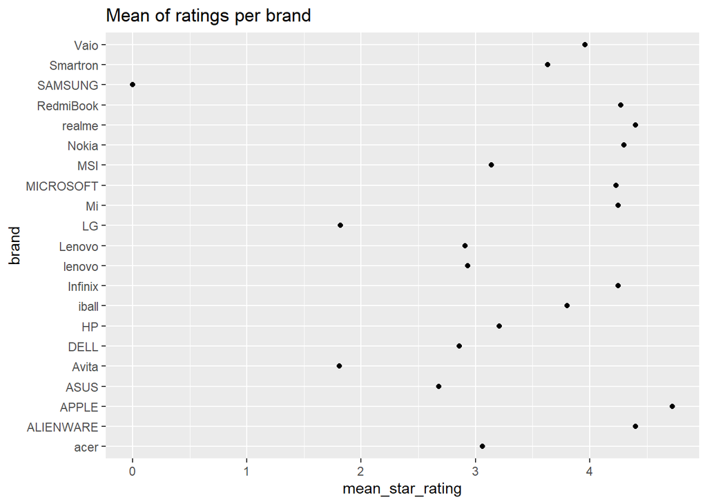

```r
library(ggplot2)
mean_per_brand_table %>%
  ggplot(aes(x=mean_star_rating, y=brand))+
  geom_point()+
  geom_smooth(method = "lm", se = FALSE)+
  labs(title = "Mean of ratings per brand")
```

#The plot is good, but a barplot would be more appropriate to have a better visibility on it !

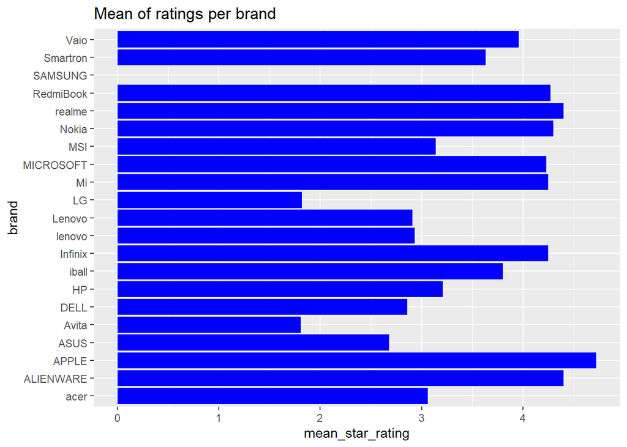

```r
library(ggplot2)
mean_per_brand_table %>%
  ggplot(aes(x=mean_star_rating, y=brand))+
  geom_bar(stat = 'identity', fill="Blue")+
  theme_grey() +
  labs(title = "Mean of ratings per brand")
```

#As wepreviously saw, the top 5 brands per star rating are again Apple ! Followed realme, Alienware, Nokia and Redmibook

#We previously created a tool that helped us to select the best laptops according to the features we chose. It is good but we also want to have a better view on it, and so far, we havent adapted to a manufacturer point of view in order to get a better sales strategy, lets to do it on a manufacturer point of view, by obeserving it depending on which component laptops perform better.

#We create then a box plot showing which laptop get the best star_rating depending on its processor, as I stated before, the idea of this project is to create toolsto help both manufacturers and byers, so each of them can modify those tools according to theirs criterias.

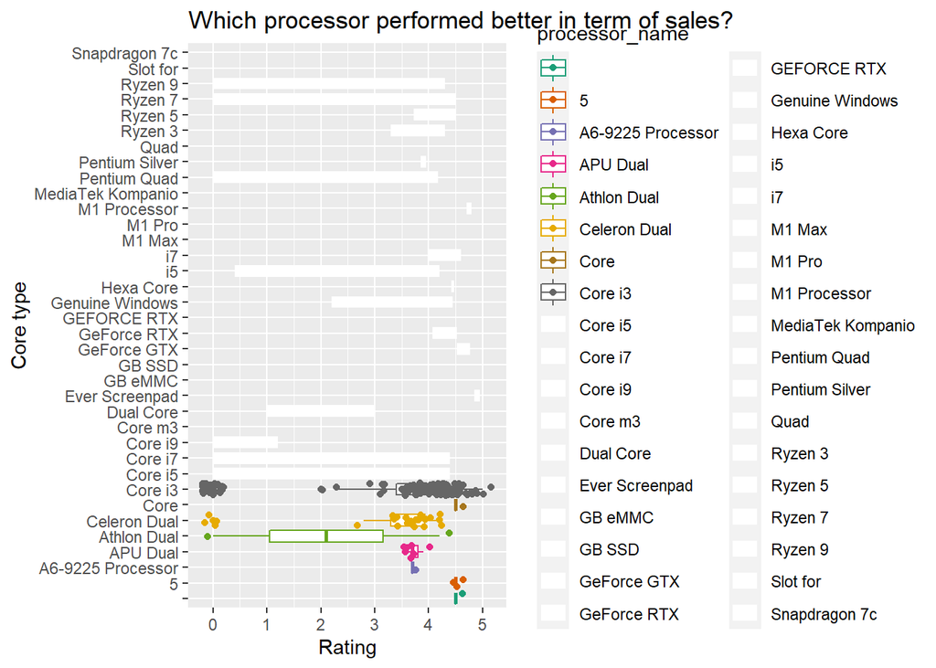

```r
laptop.df2 %>%
ggplot(aes(x=star_rating,y=processor_name, color=processor_name)) +
  geom_boxplot()+
  scale_color_brewer(palette="Dark2") +
  geom_jitter(shape=16, position=position_jitter(0.2))+
  labs(title = 'Which processor performed better in term of sales?',
       y='Core type',x='Rating')
```

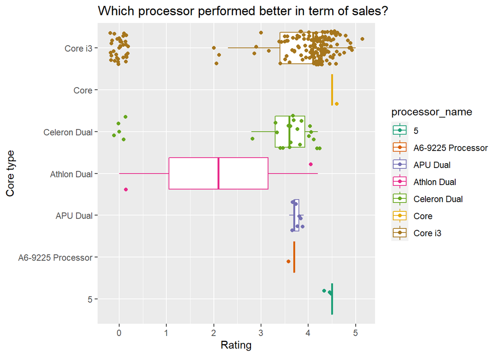

```r
#Since there are information about cores missing, the boxplot is a bit messy, lets create a dataframe  with only the processors recorded and then make the plot

laptop_processor_df <- laptop.df2
laptop_processor_df <- laptop.df2 %>%
  filter(processor_name == "5"|
         processor_name == "A6-9225 Processor"|
         processor_name == "APU Dual"|
         processor_name == "Athlon Dual"|
         processor_name == "Celeron Dual"|
         processor_name == "Core"|
         processor_name == "Core i3")%>%
  arrange(processor_name)%>%
  group_by(brand)

#creation of the plot

laptop_processor_df %>%
ggplot(aes(x=star_rating,y=processor_name, color=processor_name)) +
  geom_boxplot()+
  scale_color_brewer(palette="Dark2") +
  geom_jitter(shape=16, position=position_jitter(0.2))+
  labs(title = 'Which processor performed better in term of sales?',
       y='Core type',x='Rating')
```

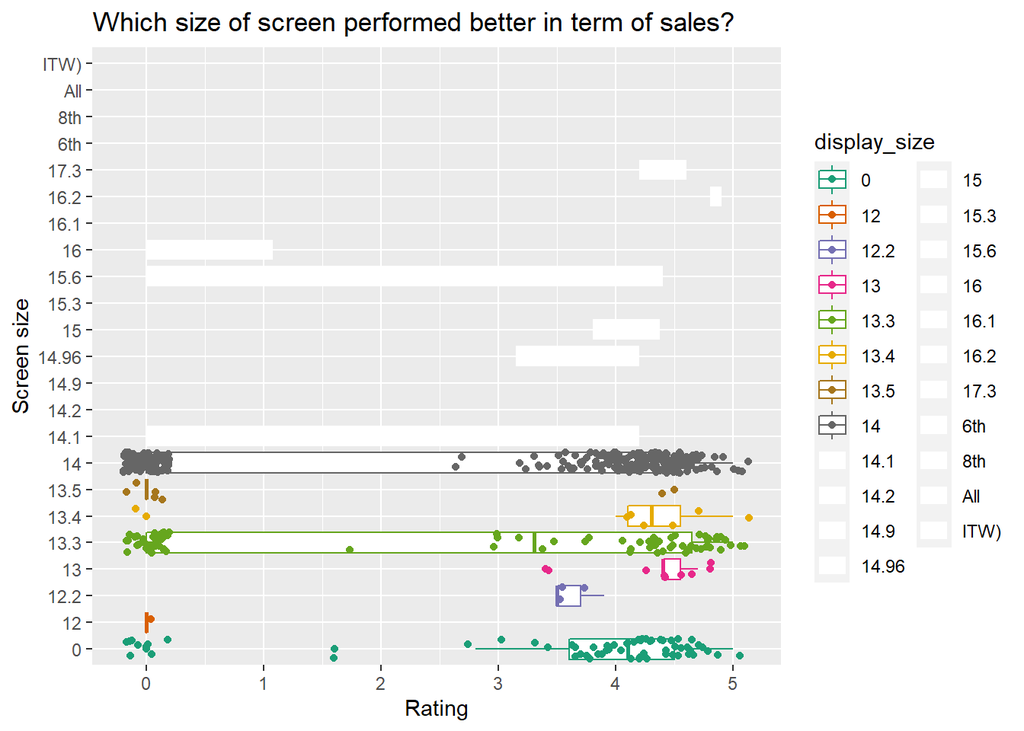

```r
laptop.df2 %>%
ggplot(aes(x=star_rating,y=display_size, color=display_size)) +
  geom_boxplot()+
  scale_color_brewer(palette="Dark2") +
  geom_jitter(shape=16, position=position_jitter(0.2))+
  labs(title = 'Which size of screen performed better in term of sales?',
       y='Screen size',x='Rating')
```

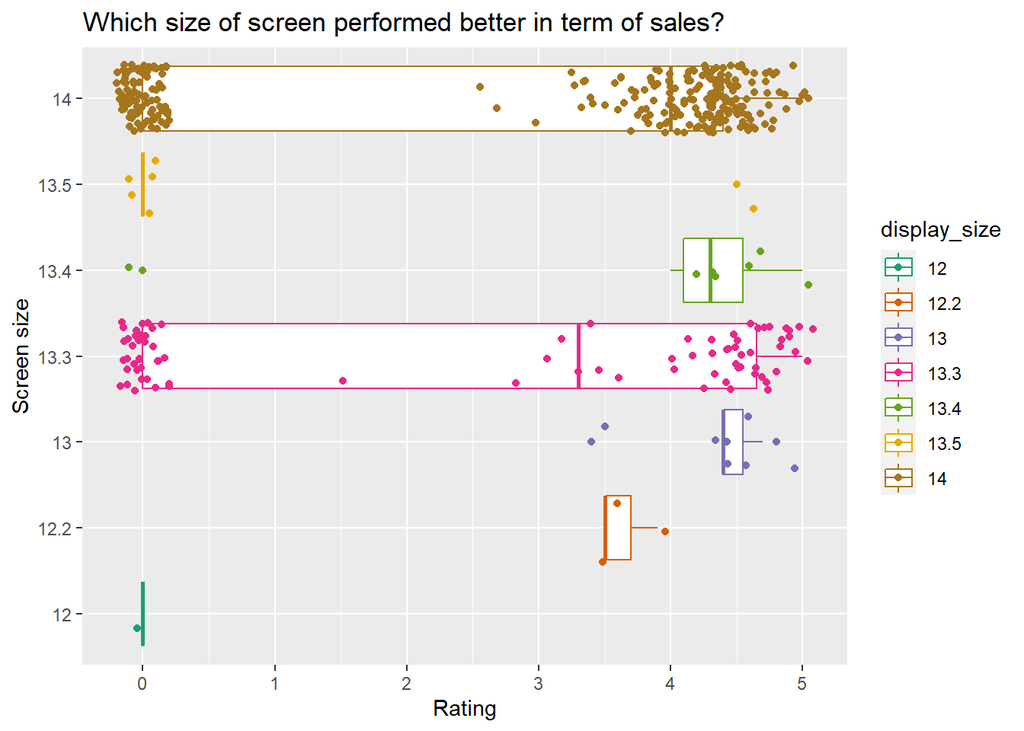

```r
#Again the data is a bit messy, and the plot take in account screen size that are 0 which means that the information isnt given, but the plot is much less messy than the processors one, again lets add a filter

laptop_display_df <- laptop.df2
laptop_display_df <- laptop.df2 %>%
  filter(display_size == "12"|
         display_size == "12.2"|
         display_size == "13"|
         display_size == "13.3"|
         display_size == "13.4"|
         display_size == "13.5"|
         display_size == "14")%>%
  arrange(processor_name)%>%
  group_by(brand)

#creation of the plot

laptop_display_df %>%
ggplot(aes(x=star_rating,y=display_size, color=display_size)) +
  geom_boxplot()+
  scale_color_brewer(palette="Dark2") +
  geom_jitter(shape=16, position=position_jitter(0.2))+
  labs(title = 'Which size of screen performed better in term of sales?',
       y='Screen size',x='Rating')
```

#We created tools for customers and manufacturers ! It is good to create such tools, but if we were at the place of manufacturers, we would also have not only tools that report our results but also ones that allow us to predict what we will create to be even more efficient in the future. In order to do so, we need to build a tool that allow us to observ the correlation between the ratings and the feature that we choose, so the features which have the best correlation will allow us to build laptops answering the demand of customers.

#Previously, we have seen that Apple was the brand with the best ratings, but it is also the brand with the highest prices, which led us to this question : Is the rating correlated to the price for each brand ? Lets create a Correlation plot to investigate this.

```r
correlation_plot_df = laptop.df2[,c(1,18,20)]

res = cor(correlation_plot_df[,-1])
res
```

```
##                      latest_price_dollars star_rating
## latest_price_dollars            1.0000000  -0.1619252
## star_rating                    -0.1619252   1.0000000
```

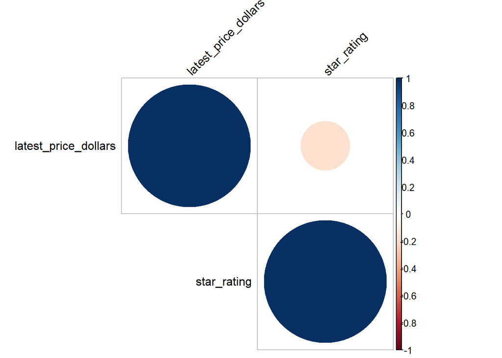

```r
library("Hmisc")
res2 <- rcorr(as.matrix(correlation_plot_df[,-1]))

library(corrplot)
corrplot(res, type = "upper", order = "hclust",
         tl.col = "black", tl.srt = 45)
```

# 5-Interpretation/Conclusion

#As we wanted to, we created tools that allow customers to choose theirs laptops depending on theirs tastes and features they care about, we walso created tools for manufacturers, and we create visualization tools that show what I just said and even more for the manufacturers so they can be more predictive ! I hope you’ve been pleased by work and if you need any further information or have better codes and tools ! Dont be shy and comment my work !

# 6-References

#Mr Uros Gudnov and his courses for some codes #sthda, stackoverflow, cfss.uchicago.edu, towardsdatascience and others websites #kaggle for the dataset, which you can find here : https://www.kaggle.com/datasets/kuchhbhi/2022-march-laptop-data?resource=download